**Computational Statistic Week 3**

## WATRIGANT Timothée

### Exercice 6.7 traité à l'écrit

### Exercices 7.1, 7.2, 7.6, 7.12, 7.24, 8.5 et 9.2 traités sous R

#### Exercice 6.7

[figure not shown]

### Exercice 7.1

##### Accept-Reject

Dans l'énoncé, une erreur sur la gamma pour la variable aléatoire de l'Accept-Reject, puisque la loi proposée (Gamma(4,7)) avait des queues de distribution plus fine que la loi que l'on cherche (Gamma(4.3,6.2)). Nous allons donc travailler avec la loi Gamma(4,6) qui elle possède bien des queues de distribution plus épaisse que la loi que l'on cherche.

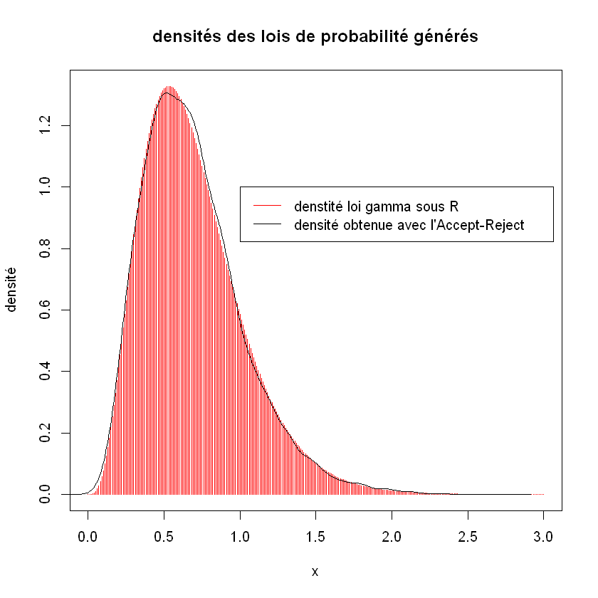

```r
#Accept-Reject
iterations = 10000
alpha=4
beta=6
alphai=4.3
betai=6.2
#Determination constant
f<-function(x){
  dgamma(x, 4.3,6.2)/dgamma(x,4,6)
}
C <- optimise(f,interval=c(0,10),maximum=TRUE)$objective

# Initialisation variables
X <- numeric(length = iterations)
a <- logical(length = iterations)

for (r in (2:iterations)) {
  ## Obtain a proposed value
  proposal <- rgamma(n=1,alpha,rate=beta)

  ## Evaluate both densities at the proposed value
  target_density_value   <- dgamma(proposal,alphai,rate=betai)
  proposal_density_value <- C*dgamma(proposal,alpha,rate=beta)

  ## This is assured to be [0,1]
  acceptance_ratio <- (target_density_value / proposal_density_value)

  ## If U(0,1) is less than or equal to acceptance ratio, accept
  if(runif(n = 1) <= acceptance_ratio) {
    a[r] <- TRUE
    X[r] <- proposal
  }
  else{
    X[r]<-X[r-1]
  }
}

x=seq(0,3,0.01)

plot(x,dgamma(x,alphai,rate=betai),ylab="densité",xlab="x",type="h",col="red",main="densités des lois de probabilité générés")
lines(density(X))
legend(1,1,legend=c("denstité loi gamma sous R","densité obtenue avec l'Accept-Reject"),col=c("red","black"),lty=1)
```

On voit que les deux courbes de densité sont très proches (densité réelle en rouge et densité estimée par Accept-Reject en noir)

##### Metropolis 1

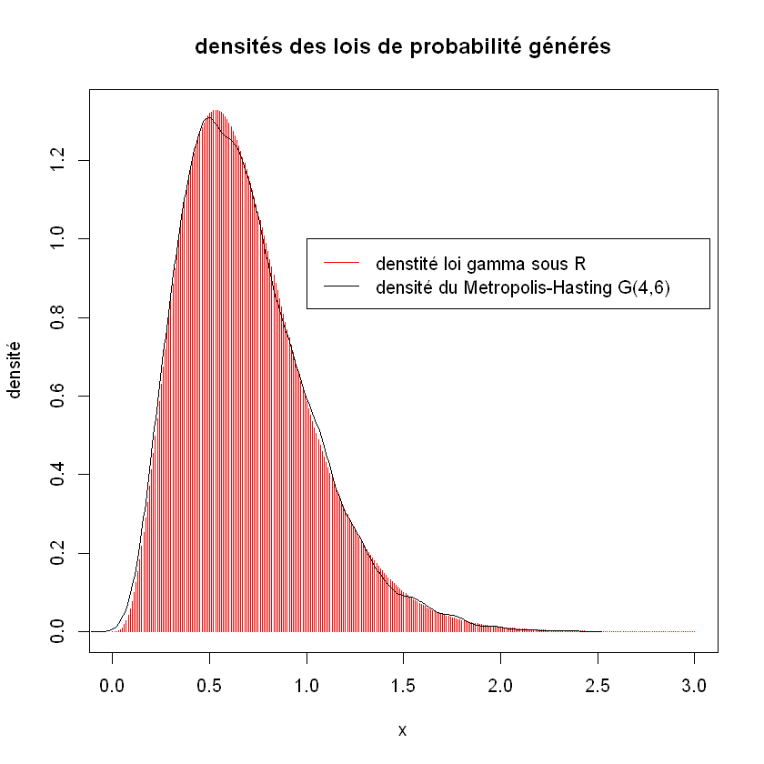

```r
#Metropolis 1 Gamma(4,6)
iterations = 10000
alpha=4
beta=6


# Initialisation variables

X1<-rep(runif(1),iterations)
#X1 <- numeric(length = iterations)
a <- logical(length = iterations)

for (r in (2:iterations)) {
  ## Obtain a proposed value
  proposal <- rgamma(n=1,alpha,rate=beta)

  ## Evaluate both densities at the proposed value
  target_density_value   <- dgamma(proposal,alphai,rate=betai)
  proposal_density_value <- dgamma(proposal,alpha,rate=beta)
  target_density_value1   <- dgamma(X1[r-1],alphai,rate=betai)
  proposal_density_value1 <- dgamma(X1[r-1],alpha,rate=beta)

  ## This is assured to be [0,1]
  acceptance_ratio <- min((target_density_value / proposal_density_value)*(proposal_density_value1/target_density_value1),1)

  ## If U(0,1) is less than or equal to acceptance ratio, accept
  if(runif(n = 1) <= acceptance_ratio) {
    a[r] <- TRUE
    X1[r] <- proposal
  }
  else{
    X1[r]<-X1[r-1]
  }
}

x=seq(0,3,0.01)

plot(x,dgamma(x,alphai,rate=betai),ylab="densité",xlab="x",type="h",col="red",main="densités des lois de probabilité générés")
lines(density(X1))
legend(1,1,legend=c("denstité loi gamma sous R","densité du Metropolis-Hasting G(4,6)"),col=c("red","black"),lty=1)
```

On voit qu'avec un Metropolis-Hastings, on obtient des résultats très similaires à ceux de l'Accept-Reject.

##### Metropolis 2

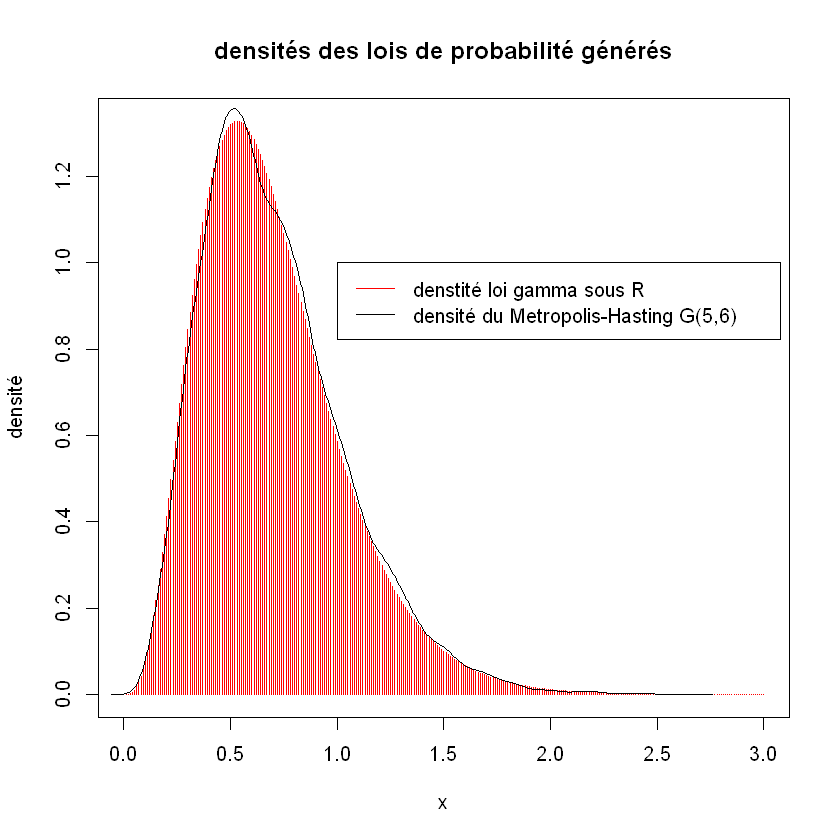

```r
#Metropolis 2 Gamma (5,6)
iterations = 10000
alpha=5
beta=6


# Initialisation variables
X2<-rep(runif(1),iterations)
#X2 <- numeric(length = iterations)
a <- logical(length = iterations)

for (r in (2:iterations)) {
  ## Obtain a proposed value
  proposal <- rgamma(n=1,alpha,rate=beta)

  ## Evaluate both densities at the proposed value
  target_density_value   <- dgamma(proposal,alphai,rate=betai)
  proposal_density_value <- dgamma(proposal,alpha,rate=beta)
  target_density_value1   <- dgamma(X2[r-1],alphai,rate=betai)
  proposal_density_value1 <- dgamma(X2[r-1],alpha,rate=beta)

  ## This is assured to be [0,1]
  acceptance_ratio <- min((target_density_value / proposal_density_value)*(proposal_density_value1/target_density_value1),1)

  ## If U(0,1) is less than or equal to acceptance ratio, accept
  if(runif(n = 1) <= acceptance_ratio) {
    a[r] <- TRUE
    X2[r] <- proposal
  }
  else{
    X2[r]<-X2[r-1]
  }
}

x=seq(0,3,0.01)

plot(x,dgamma(x,alphai,rate=betai),,ylab="densité",xlab="x",type="h",col="red",main="densités des lois de probabilité générés")
lines(density(X2))
legend(1,1,legend=c("denstité loi gamma sous R","densité du Metropolis-Hasting G(5,6)"),col=c("red","black"),lty=1)
```

Bien que l'on ait pas la même loi que pour l'Accept-Reject, on a des résultats similaires, lorsque l'on a suffissament d'itérations.

```
[1] 0.690215
[1] 0.6869704
[1] 0.7039242
```

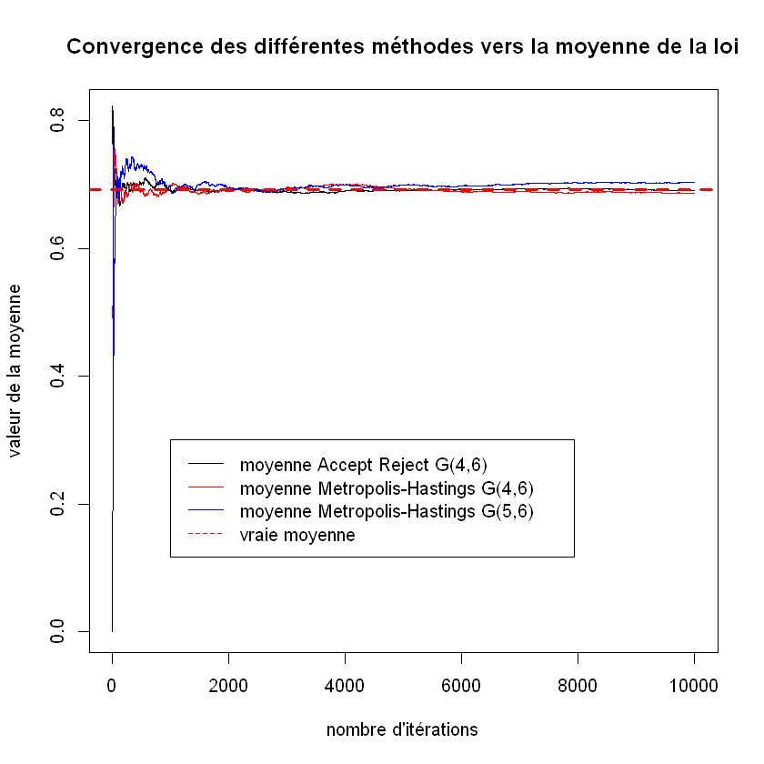

```r
plot(cumsum(X)/1:iterations,type="l",main="Convergence des différentes méthodes vers la moyenne de la loi",xlab="nombre d'itérations",ylab="valeur de la moyenne")
print(mean(X))

lines(cumsum(X1)/1:iterations,type="l",col="red")
print(mean(X1))

lines(cumsum(X2)/1:iterations,type="l",col="blue")
print(mean(X2))

moyenne=mean(rgamma(10000,alphai,rate=betai))
abline(moyenne, 0, col = "red", lw = 3, lty = 2)

legend(1000,0.3,legend=c("moyenne Accept Reject G(4,6)","moyenne Metropolis-Hastings G(4,6)","moyenne Metropolis-Hastings G(5,6)","vraie moyenne"),col=c("black","red","blue","red"),lty=c(1,1,1,2))
```

On voit que l'on a convergence pour les trois méthodes de façon très proche. Nous allons sur la partie qui nous intéresse afin de mieux déterminer s'il y a tout de même des divergences.

```
[1] 0.690215
[1] 0.6869704
[1] 0.7039242
```

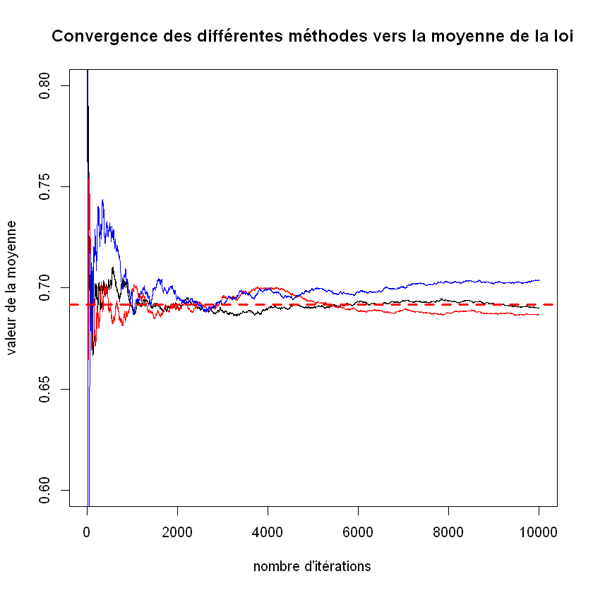

```r
plot(cumsum(X)/1:iterations,type="l",ylim=c(0.6,0.8),main="Convergence des différentes méthodes vers la moyenne de la loi",xlab="nombre d'itérations",ylab="valeur de la moyenne")
print(mean(X))

lines(cumsum(X1)/1:iterations,type="l",col="red")
print(mean(X1))

lines(cumsum(X2)/1:iterations,type="l",col="blue")
print(mean(X2))

moyenne=mean(rgamma(10000,alphai,rate=betai))
abline(moyenne, 0, col = "red", lw = 3, lty = 2)

legend(1000,0.3,legend=c("moyenne Accept Reject G(4,6)","moyenne Metropolis-Hastings G(4,6)","moyenne Metropolis-Hastings G(5,6)","vraie moyenne"),col=c("black","red","blue","red"),lty=c(1,1,1,2))
```

L'avantage de la méthode de Métropolis-Hastings est que l'on n'a pas besoin de définir une constante M (contrairement à l'Accept-Reject). L'échantillon d'Accept-Reject est indépendant identiquement distribué contrairement au cas de Metropolis-Hasting. Metropolis-Hasting est un cas général d'Accept-Reject qui pourrait être défini dans une fonction qui nécessite aucune définition de constante, mais dans le cas où il n'y pas de contanste entre les fonctions, l'algorithme de Metropolis-Hastings peut-être très long.

#### Exercice 7.2

##### Metropolis 1

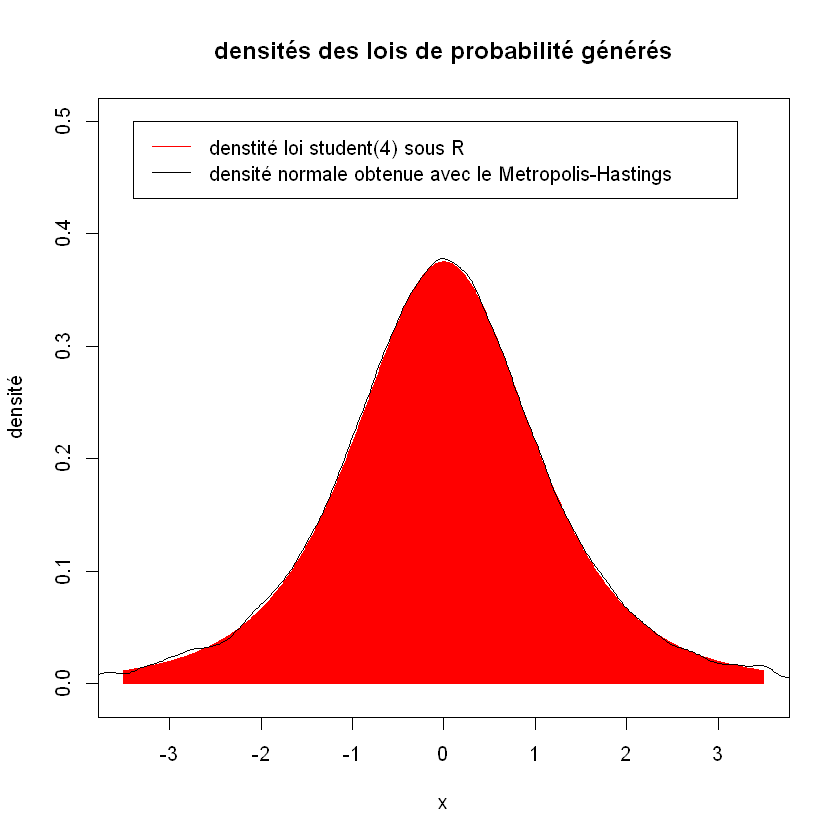

```r
Student = function(x,nu) {(gamma((nu+1)/2)/gamma(nu/2))*(1/sqrt(pi*nu))*(1+((x^2)/nu))^((-nu-1)/2)}


#Metropolis 1
iterations = 100000
n = 1:iterations
mean=0
var=1


# Initialisation variables
X1<-rep(runif(1),iterations)
a1 <- logical(length = iterations)

for (r in (2:iterations)) {
  ## Obtain a proposed value
  proposal <- rnorm(n=1,mean,var)

  ## Evaluate both densities at the proposed value
  target_density_value   <- Student(proposal,4)
  proposal_density_value <- dnorm(proposal,mean,var)
  target_density_value1   <- Student(X1[r-1],4)
  proposal_density_value1 <- dnorm(X1[r-1],mean,var)


  ## This is assured to be [0,1]
  acceptance_ratio <- min((target_density_value / proposal_density_value)*(proposal_density_value1/target_density_value1),1)

  ## If U(0,1) is less than or equal to acceptance ratio, accept
  if(runif(n = 1) <= acceptance_ratio) {
    a1[r] <- TRUE
    X1[r] <- proposal
  }
  else{
    X1[r]<-X1[r-1]
  }
}


x=seq(-3.5,3.5,0.01)

plot(x,dt(x,4),ylab="densité",ylim=c(-0.01,0.5),xlab="x",type="h",col="red",main="densités des lois de probabilité générés")
lines(density(X1))
legend(-3.4,0.5,legend=c("denstité loi student(4) sous R","densité normale obtenue avec le Metropolis-Hastings"),col=c("red","black"),lty=1)
```

On voit que l'on obtient une densité très proche de la densité réelle de la fonction estimée par la méthode de Métropolis-Hastings.

##### Metropolis 2

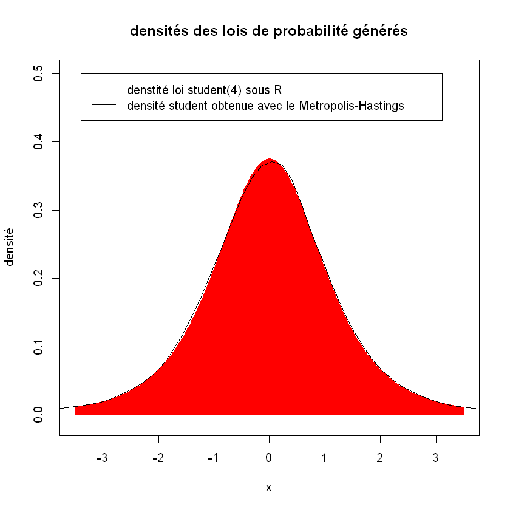

```r
#Metropolis 2


# Initialisation variables
X2<-rep(runif(1),iterations)
a2 <- logical(length = iterations)

for (r in (2:iterations)) {
  ## Obtain a proposed value
  proposal <- rt(1,2)

  ## Evaluate both densities at the proposed value
  target_density_value   <- Student(proposal,4)
  proposal_density_value <- Student(proposal,2)
  target_density_value1   <- Student(X2[r-1],4)
  proposal_density_value1 <- Student(X2[r-1],2)

  ## This is assured to be [0,1]
  acceptance_ratio <- min((target_density_value / proposal_density_value)*(proposal_density_value1/target_density_value1),1)

  ## If U(0,1) is less than or equal to acceptance ratio, accept
  if(runif(n = 1) <= acceptance_ratio) {
    a2[r] <- TRUE
    X2[r] <- proposal
  }
  else{
    X2[r]<-X2[r-1]
  }
}

x=seq(-3.5,3.5,0.01)

plot(x,dt(x,4),ylab="densité",ylim=c(-0.01,0.5),xlab="x",type="h",col="red",main="densités des lois de probabilité générés")
lines(density(X2))
legend(-3.4,0.5,legend=c("denstité loi student(4) sous R","densité student obtenue avec le Metropolis-Hastings"),col=c("red","black"),lty=1)
```

```
[1] 0.005700841
[1] -0.001878606
```

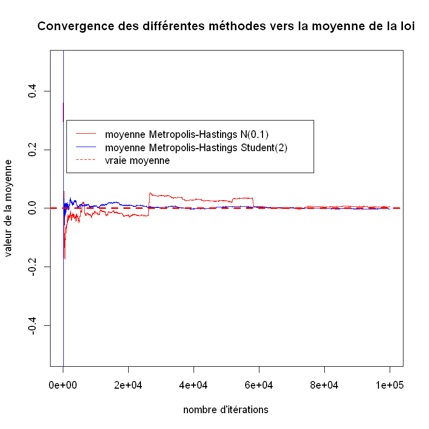

```r
plot(cumsum(X1)/1:iterations,type="l",ylim=c(-0.5,0.5),col="red",main="Convergence des différentes méthodes vers la moyenne de la loi",xlab="nombre d'itérations",ylab="valeur de la moyenne")
print(mean(X1))

lines(cumsum(X2)/1:iterations,type="l",col="blue")
print(mean(X2))

r<-c()
for (i in 1:iterations)
{
  r[i]<-Student(i,4)
}
moyenne=mean(r)

abline(a =moyenne, b = 0, col = "red", lw = 3, lty = 2)


legend(1000,0.3,legend=c("moyenne Metropolis-Hastings N(0.1)","moyenne Metropolis-Hastings Student(2)","vraie moyenne"),col=c("red","blue","red"),lty=c(1,1,2))
#trois valeurs de moyenne proche
```

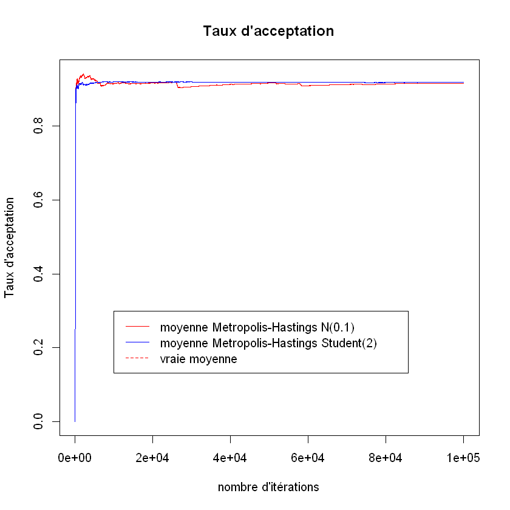

```r
plot(cumsum(a1)/1:iterations,type="l",col="red",main="Taux d'acceptation",xlab="nombre d'itérations",ylab="Taux d'acceptation")

lines(cumsum(a2)/1:iterations,type="l",col="blue")
legend(10000,0.3,legend=c("moyenne Metropolis-Hastings N(0.1)","moyenne Metropolis-Hastings Student(2)","vraie moyenne"),col=c("red","blue","red"),lty=c(1,1,2))
```

#### Exercice 7.6

Commençons par calculer la distribution stationnaire f, grâce à la formule obtenue dans le problème 7.5:

$$f(x) \propto \frac{g(x)}{1-\rho(x)}\propto \frac{x^{\alpha-1+1}}{x}\propto x^{\alpha-1}$$

```
[1] 0.3799026
```

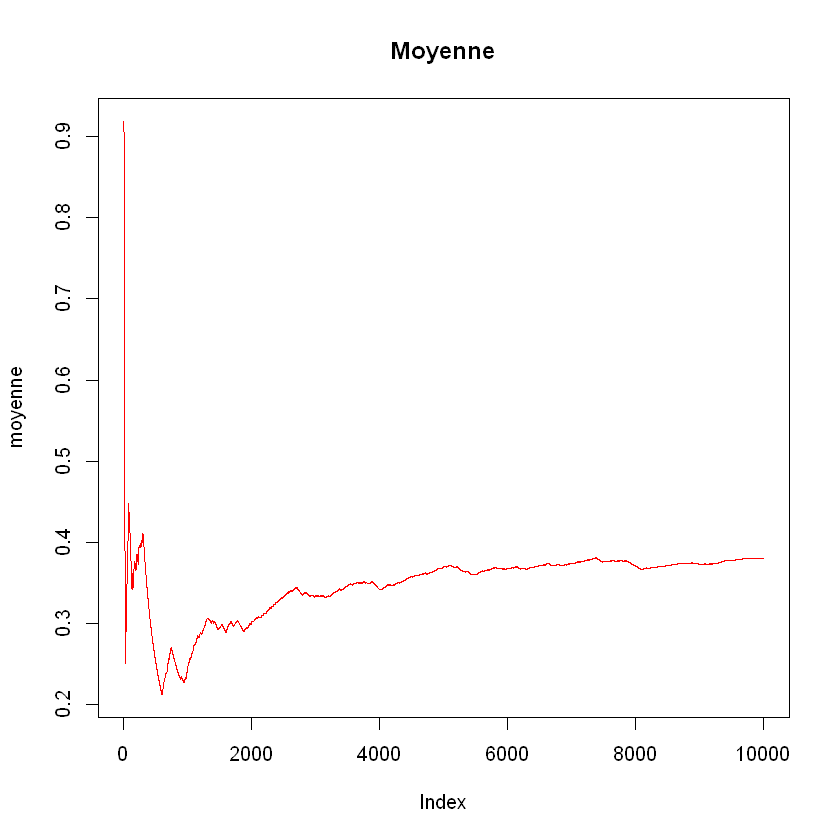

```r
#Repeat or Simulate

Repeat <- function(alpha, n){
  x <- runif(1)
  a <- 0
  for (i in 2:n){
    u <- runif(1)
    if (u > 1-x[i-1]){
      x [i]<- rbeta(1, alpha + 1, 1)
      a <- a+1
    }
    else{
      x[i]<- x[i-1]
    }
  }
  return(list("a" = a/n, "X" = x))
}

#convergence
iterations = 10000
alpha=0.6
X=Repeat(alpha,iterations)$X
plot(cumsum(X)/1:iterations,type="l",col="red",ylab="moyenne",main="Moyenne")

#valeurs de la moyenne
print(mean(X))
```

```
[1] "For alpha = 0.7, the acceptance rate is 0.4278"
[1] "For alpha = 0.8, the acceptance rate is 0.4714"
[1] "For alpha = 0.9, the acceptance rate is 0.4792"
[1] "For alpha = 1, the acceptance rate is 0.516"
[1] "For alpha = 1.1, the acceptance rate is 0.5256"
[1] "For alpha = 1.2, the acceptance rate is 0.5425"
[1] "For alpha = 1.3, the acceptance rate is 0.56"
```

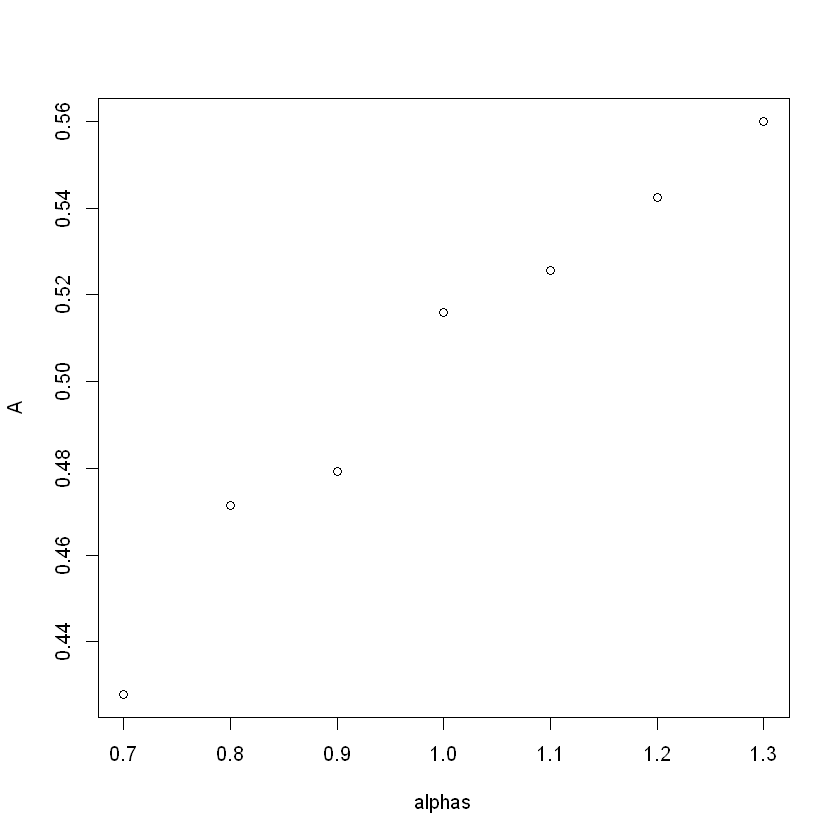

```r
alphas <- c(0.7, 0.8,  0.9, 1, 1.1, 1.2, 1.30)
A <- vector(length = length(alphas))
for (i in 1:length(alphas)){
  sim <- Repeat(alpha = alphas[i], iterations)
  A[i] <- sim$a
  print(paste0("For alpha = ", alphas[i], ", the acceptance rate is ", A[i]))
}
plot(alphas, A)
```

#### Exercice 7.12

```r
iterations=5000
mean=0
var=1


Metropolis <- function(delta){
  a <- logical(length = iterations)
  X=rep(runif(1),iterations)

  for (r in (2:iterations)) {
    ## Obtain a proposed value
    Y<-runif(n=1,min=-delta,max=delta)

    ## This is assured to be [0,1] et comme on a une loi uniforme avec le même intervalle (-delta-x;delta-x), on aura les mêmes valeurs de densité lorsque l'on applique la densité à x ou y (q(x|y)=q(y|x), q est symétrique), on peut limiter la proba à
    acceptance_ratio <- min(dnorm(Y,mean,var)/dnorm(X[r-1],mean,var),1)

    ## If U(0,1) is less than or equal to acceptance ratio, accept
    X[r]=X[r-1] + (Y-X[r-1])*(runif(1)<acceptance_ratio)
    a[r]=1*(runif(1)<acceptance_ratio)
  }
  quantile=quantile(X,0.9)-quantile(X,0.1)
  mylist<-list("X"=X,"a"=a,"quantile"=quantile)
  return(mylist)
}
```

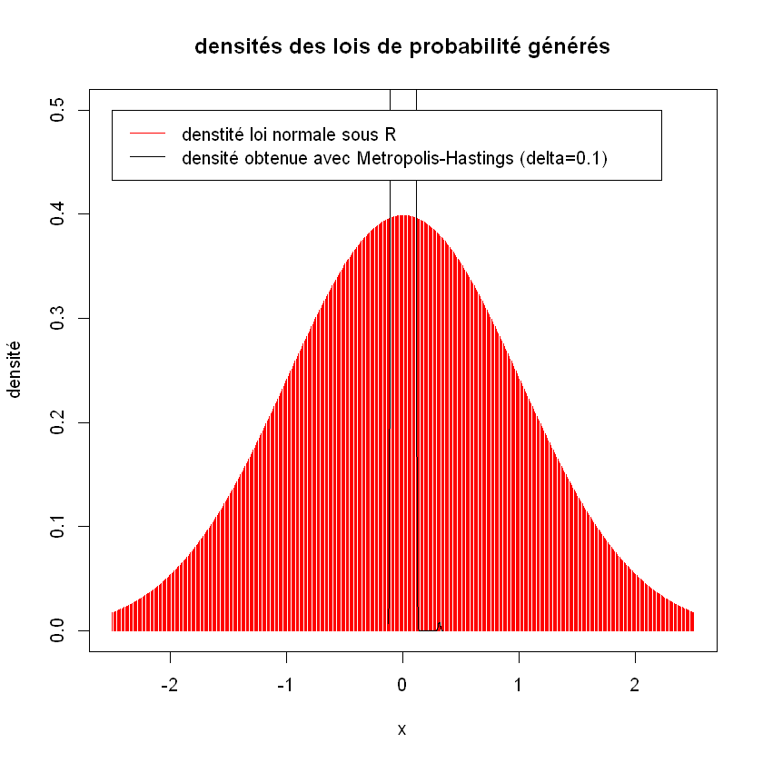

```r
M01=Metropolis(0.1)
X1<-M01$X
M1=Metropolis(1)
X2<-M1$X
M10=Metropolis(10)
X3<-M10$X


x=seq(-2.5,2.5,0.01)
plot(x,dnorm(x,mean,1),ylim=c(0,0.5),ylab="densité",xlab="x",type="h",col="red",main="densités des lois de probabilité générés")
lines(density(X1))
legend(-2.5,0.5,legend=c("denstité loi normale sous R","densité obtenue avec Metropolis-Hastings (delta=0.1)"),col=c("red","black"),lty=1)
```

On voit que pour un delta très faible, la densité approximée par la méthode de Matropolis-Hastings est loin d'être celle souhaitée puisque l'on n'a pas la bonne variance mais la moyenne reste la bonne.

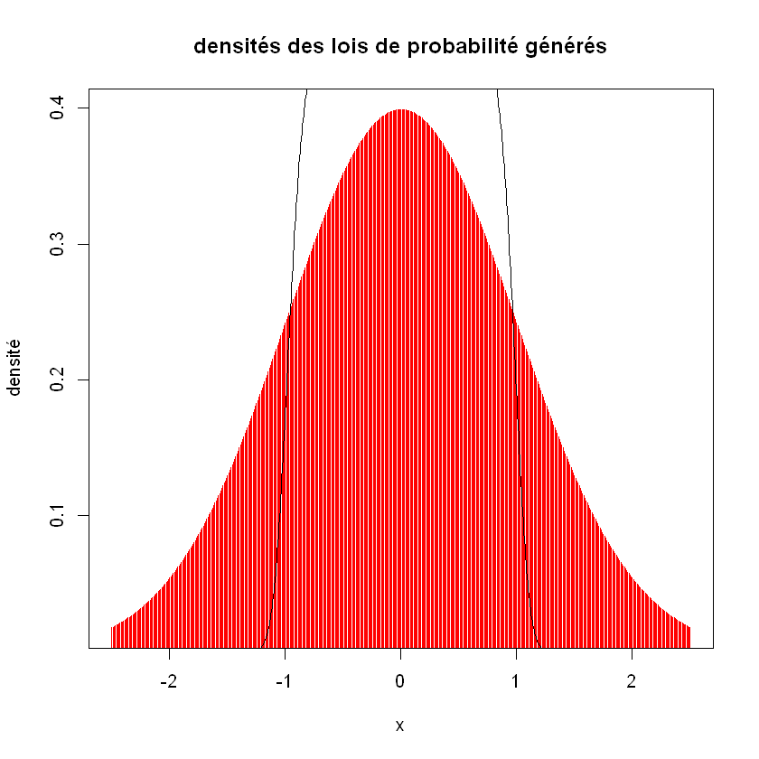

```r
x=seq(-2.5,2.5,0.01)
plot(x,dnorm(x,mean,1),ylab="densité",xlab="x",type="h",col="red",main="densités des lois de probabilité générés")
lines(density(X2))
legend(-2.5,0.5,legend=c("denstité loi normale sous R","densité obtenue avec Metropolis-Hastings (delta=1)"),col=c("red","black"),lty=1)
```

On voit qu'en augmentant le delta, on se rapproche de la "bonne" densité avec une variance qui augmente.

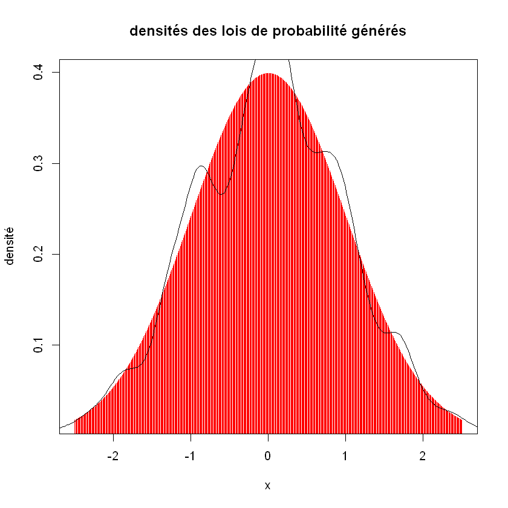

```r
x=seq(-2.5,2.5,0.01)
plot(x,dnorm(x,mean,1),ylab="densité",xlab="x",type="h",col="red",main="densités des lois de probabilité générés")
lines(density(X3))
legend(-2.5,0.5,legend=c("denstité loi normale sous R","densité obtenue avec Metropolis-Hastings (delta=10)"),col=c("red","black"),lty=1)
```

Dans le cas où delta vaut 10, on approxime plutôt bien la loi normale avec une variance et une moyenne porche de celle attendue.

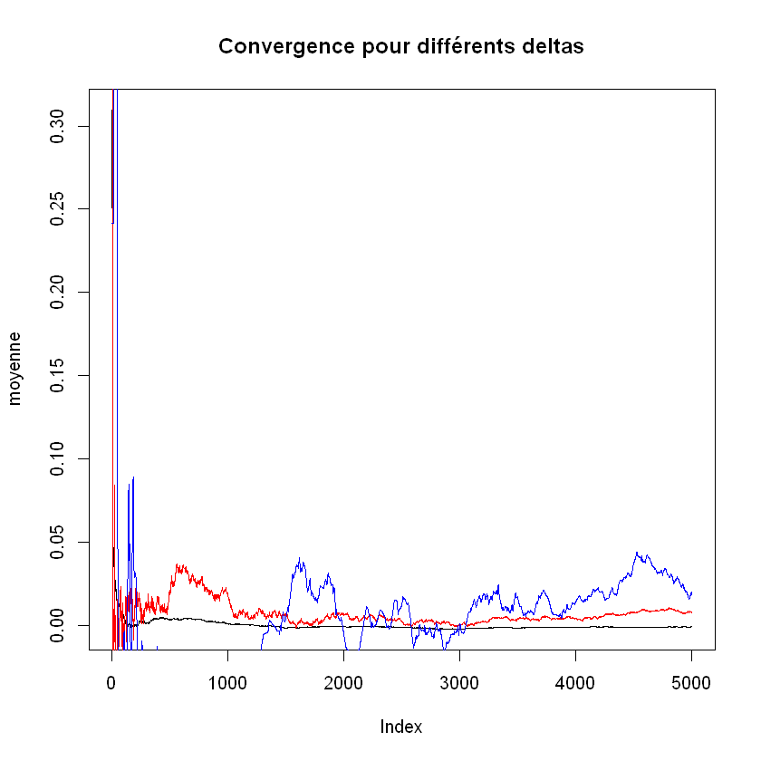

```r
plot(cumsum(X1)/1:iterations,type="l",main="Convergence pour différents deltas",ylab="moyenne")
lines(cumsum(X2)/1:iterations,type="l",col="red")
lines(cumsum(X3)/1:iterations,type="l",col="blue")
legend(1500,0.4,legend=c("moyenne Metropolis-Hastings delta=0.1","moyenne Metropolis-Hastings delta=1","moyenne Metropolis-Hastings delta=10"),col=c("black","red","blue"),lty=c(1,1,1))
```

On voit que la moyenne converge plus rapidement (en nombre d'itérations) pour un delta plus petit, ce qui est normal pour qu'on limite les valeurs autour de 0.

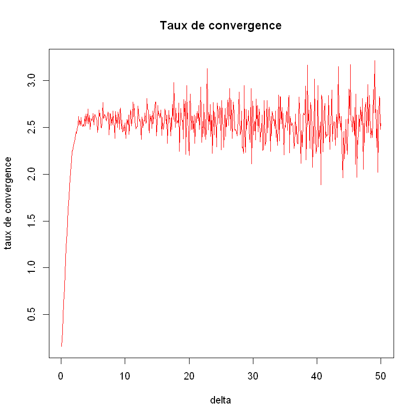

```r
quantile1<-c()
x=seq(0.1,50,0.1)
for(i in 1:length(x)){
  M=Metropolis(i/10)
  quantilei<-M$quantile
  quantile1[i]=quantilei
}
plot(x,quantile1,type="l",col="red",main="Taux de convergence",xlab="delta",ylab="taux de convergence")
```

On voit que le taux de convergence tend vers la bonne valeur de taux de convergence de 2.56 pour 90%, lorsque le delta augmente mais une variance de plus en plus importante apparait (qui pourrait être réduit si on moyenne les valeurs de quantile sur 10 ou 100 itérations, mais cela nécessite un temps d'exécution beaucoup plus important).

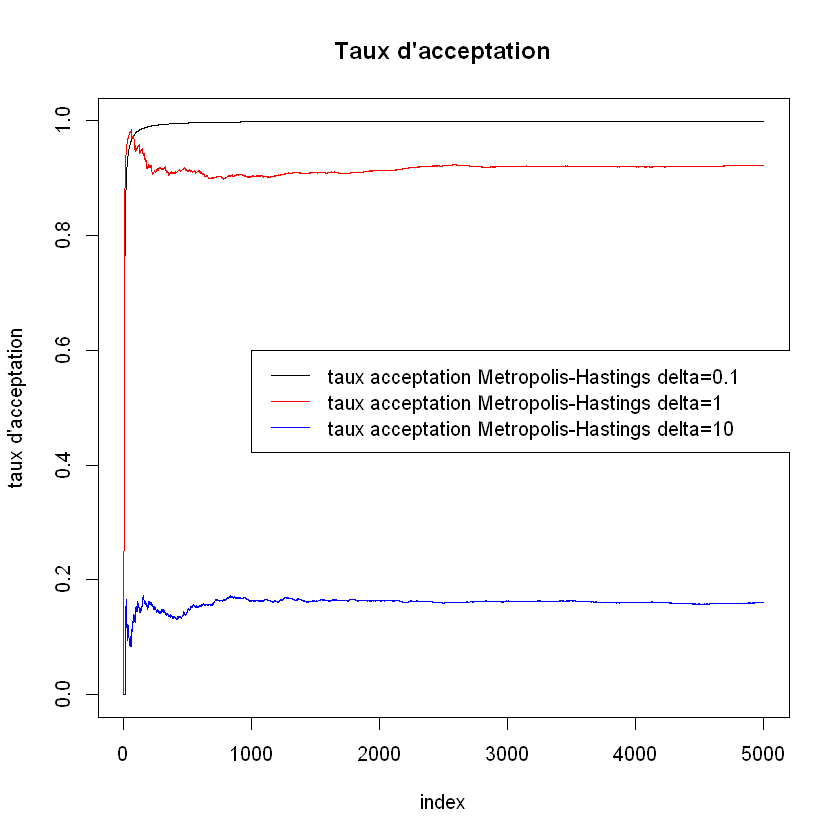

```r
A1<-M01$a
A2<-M1$a
A3<-M10$a
plot(cumsum(A1)/1:iterations,type="l",main="Taux d'acceptation",ylab="taux d'acceptation",xlab="index")
lines(cumsum(A2)/1:iterations,type="l",col="red")
lines(cumsum(A3)/1:iterations,type="l",col="blue")
legend(1000,0.6,legend=c("taux acceptation Metropolis-Hastings delta=0.1","taux acceptation Metropolis-Hastings delta=1","taux acceptation Metropolis-Hastings delta=10"),col=c("black","red","blue"),lty=c(1,1,1))
```

On voit que le taux d'acceptation chute lorsque le delta augmente. Nous allons maintenant regarder ce taux d'acceptation en fonction du delta:

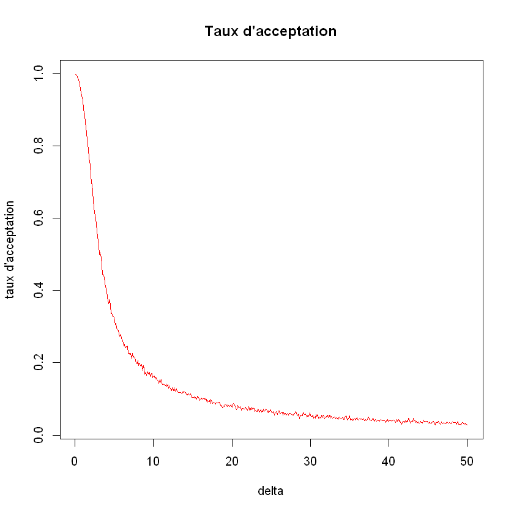

```r
A<-c()
x=seq(0.1,50,0.1)
for (i in 1:length(x)){
  M=Metropolis(i/10)
  A1<-M$a
  A[i]=sum(A1)
}

plot(x,A/iterations,type="l",col="red",main="Taux d'acceptation",ylab="taux d'acceptation",xlab="delta")
```

On voit que le taux d'acceptation part de 1, pour un delta nulle (donc la condition est toujours acceptée), pour chuter et tendre vers 0 pour un delta infini, ce qui s'explique par le fait que la loi uniforme est sur un terme très grand, donc le Y qui est calculé à partir de cette loi, tend vers un grand terme. En appliquant une densité de loi normale de moyenne nulle et de variance unitaire à ce Y (grand), on obtient quasiment 0 (puisque la loi normale ne prend quasiment jamais ces grandes valeurs), donc la condition est donc quasiment jamais vérifiée.

```
[1] 41.8
```

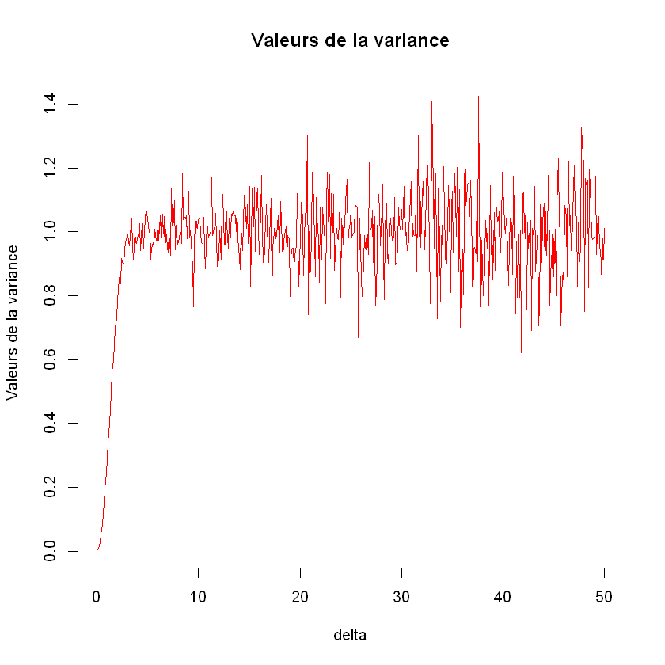

```r
V<-c()
x=seq(0.1,50,0.1)
for (i in 1:length(x)){
  M=Metropolis(i/10)
  X1<-M$X
  mu=(1/iterations)*sum(X1)
  vari=(1/(iterations-1))*((X1-mu)^2)
  V[i]=sum(vari)
}


plot(x,V,type="l",col="red",main="Valeurs de la variance",ylab="Valeurs de la variance",xlab="delta")


X0=V[100]
delta0=10
for (i in 100:length(V)){
  if (V[i]<X0){
    X0=V[i]
    delta0=i/10
  }
}
print(delta0)
```

On a le minimum quand delta tend vers 0 mais cela implique qu'en sortie, on n'aura plus vraiment une loi normale (0.1) comme vue précédemment avec les densités. Mais quand delta la variance est plus instable (variance qui augmente), mais cette variance (diminution-augmentation) n'est pas une vraie diminution de la variance, puisqu'en moyennant sur 10 itérations, on voit les valeurs minimales sur les deltas importants ont augmenté.

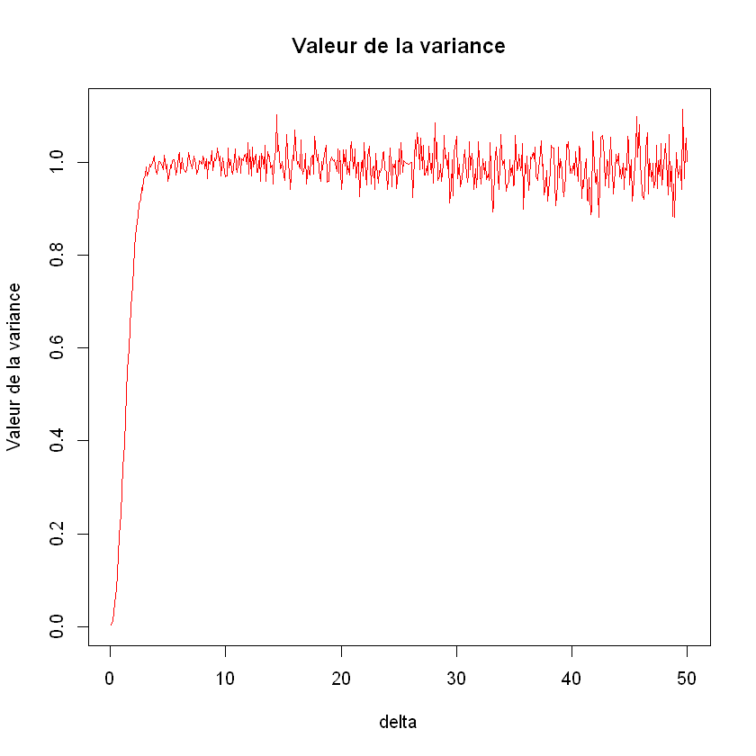

```r
V<-c()
vart<-c()
x=seq(0.1,50,0.1)
for (i in 1:length(x)){
    vari=0
    for(k in 1:10){
  M=Metropolis(i/10)
  X1<-M$X
  mu=(1/iterations)*sum(X1)
  vari=(1/(iterations-1))*((X1-mu)^2)
  vart[k]=sum(vari)
    }
  V[i]=sum(vart)/10
}


plot(x,V,type="l",col="red",main="Valeur de la variance",ylab="Valeur de la variance",xlab="delta")
```

On voit ici qu'en moyennant sur une dizaine d'itérations, la variance empirique ne présente plus de grandes fluctuations pour les deltas grands, donc on n'a pas de "vrais" minima pour des deltas grands mais des variations dû à la partie aléatoire du Y (qui peut prendre de plus en plus de valeursavec des deltas plus grands).

#### Exercice 7.24

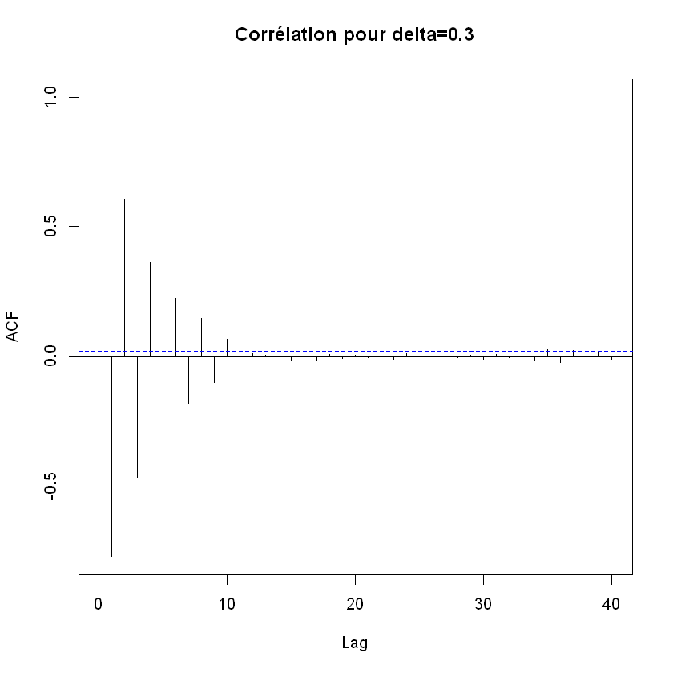

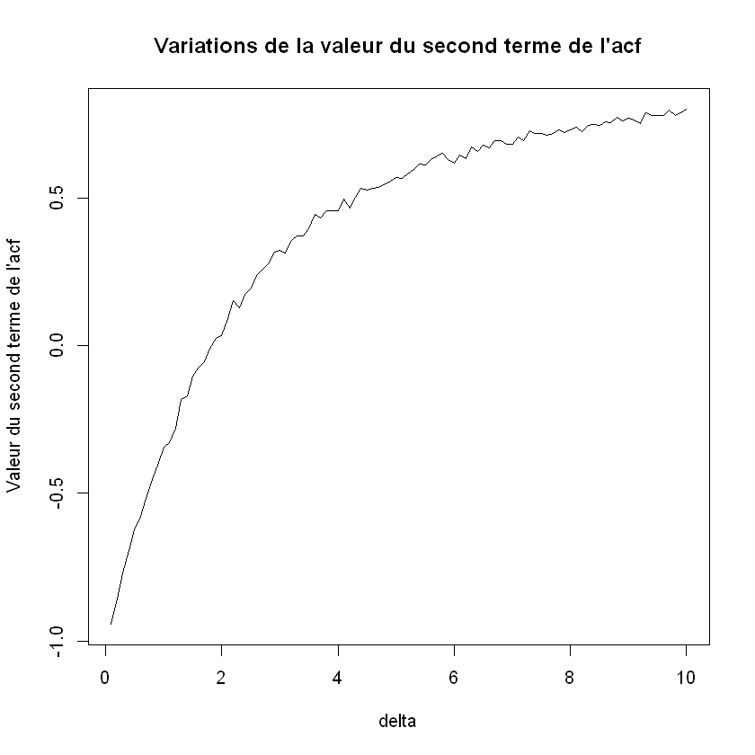

```r
iterations=10000
mean=0
var=1


Metropolis <- function(delta){

  X=rep(runif(1),iterations)

  for (r in (2:iterations)) {
    ## Obtain a proposed value
    Y<-runif(n=1,min=-delta,max=delta)-X[r-1]#valeurs manquantes si X[r-1] dans la fonction

    ## Calcul de l'acceptance ratio et comme on a une loi uniforme avec le même intervalle (-delta-x;delta-x), on aura les mêmes valeurs de densité lorsque l'on applique la densité à x ou y (q(x|y)=q(y|x), q est symétrique), on peut limiter la proba à
    acceptance_ratio <- min(dnorm(Y,mean,var)/dnorm(X[r-1],mean,var),1)

    ## If U(0,1) is less than or equal to acceptance ratio, accept
    X[r]=X[r-1] + (Y-X[r-1])*(runif(1)<acceptance_ratio)
  }
  return(X)
}


X=Metropolis(0.3)
Y=acf(X,type="correlation",main="Corrélation pour delta=0.3")

x=seq(0.1,10,0.1)
for (i in 1:100){
  X=Metropolis(i/10)
  Y=acf(X,plot=FALSE,type="correlation")
  C[i]=Y$acf[2]
  }

plot(x,C,type="l",main="Variations de la valeur du second terme de l'acf",xlab="delta",ylab="Valeur du second terme de l'acf")
```

On voit que la courbe qui représente le coefficient du second terme de l'autocorrélation, varie beaucoup puisque tout se base que des variabes aléatoires basées sur une loi normale. Les valeurs de corrélation sont négatives jusqu'à ce que delta soit suffisament grand et donc que l'intervalle pour la loi uniforme soit suffisament grand pour contenir à la fois X et -X.

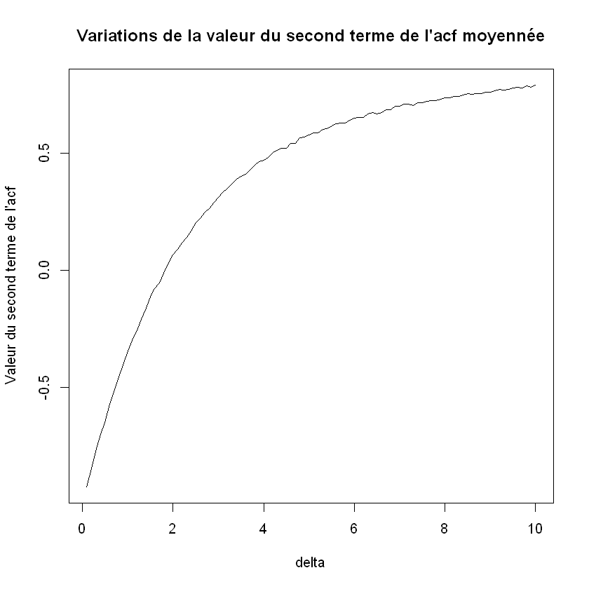

```r
x=seq(0.1,10,0.1)
for (i in 1:100){
  Z<-c()
  for (k in 1:10){
    X=Metropolis(i/10)
    Y=acf(X,plot=FALSE,type="correlation")
    Z[k]=Y$acf[2]
  }
  C[i]=mean(Z)
}

plot(x,C,type="l",main="Variations de la valeur du second terme de l'acf moyennée",xlab="delta",ylab="Valeur du second terme de l'acf")
```

Quand on moyenne sur 10 itérations, on voit que ces variations sont beaucoup moins importantes puisque la propriété aléatoire n'est plus si importante. On voit alors que l'on a le seond terme de l'acf qui tend vers -1 quand delta tend vers 0 (ce qui s'explique par le fait que l'on tend vers un singleton pour la loi uniforme) et tend vers 1 quand delta vers l'infini (puisque dans ce cas, loi uniforme prendra l'ensemble des valeurs possibles pour X (X et -X)).

#### Exercice 8.5

La fonction suit une loi de densité normale $$f(x) \propto exp{(-x^2/2)}$$.

En l'appliquant sur la première fonction du slice sampler, on trouve: $ w|x=U[0,f(x^{(t)})]=U[0, exp{(-x^2/2)}$]

Pour l'autre fonction de slice sampler, on doit résoudre en x:
$$f(x)\ge w \\ \Rightarrow exp{(-x^2/2)}\ge w \\ \Rightarrow (-x^2/2)\ge log{(w)} \\ \Rightarrow x^2/2\le -log{(w)} \\ \Rightarrow x^2\le -2 log{(w)} \\ \Rightarrow -\sqrt{(-2 log{(w)}} \le x \le \sqrt{(-2 log{(w)}} $$ On retrouve lors la deuxième fonction de l'énoncé: $ x|w=U[-\sqrt{(-2 log{(w)}}, \sqrt{(-2 log{(w)}}$]

On va maintenant implémenter l'algorithme de slice sampler pour ce cas de la loi normale (0,1).

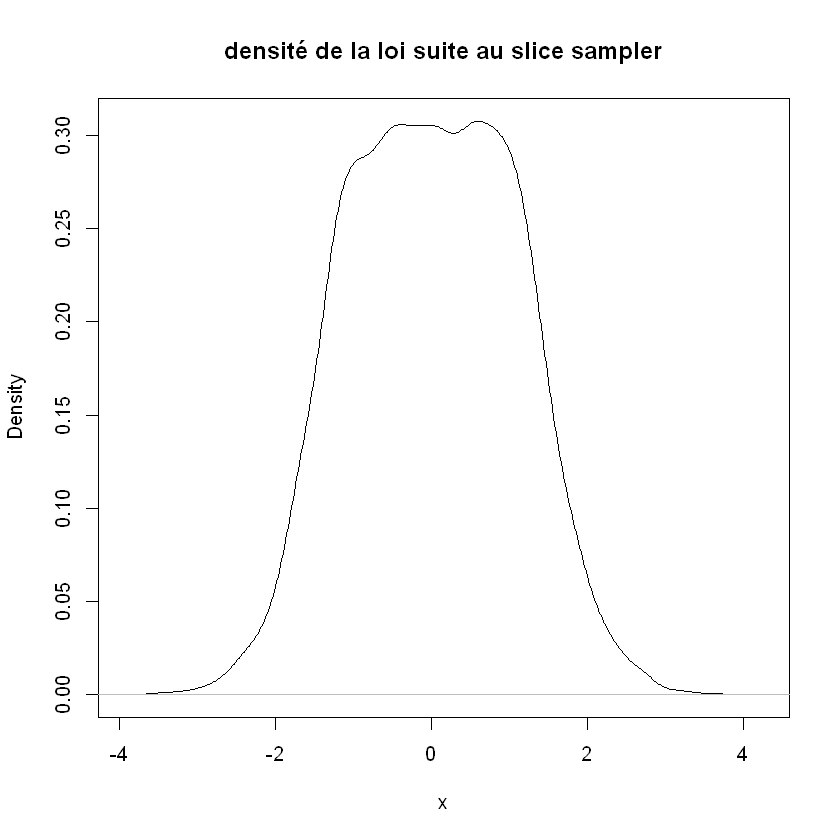

```r
iterations=10000
x0=0

f<-function(x,d){
  return (1/2)*exp(-(x^2)/2)
}
x<-rep(x0,iterations)
u<-rep(runif(1,0,f(x[1],0.5)),iterations)


for (r in 2:iterations){
  u[r]=runif(1,0,f(x[r-1],0.5))
  x[r]=runif(1,-sqrt(-2*log(u[r],base=exp(1))),sqrt(-2*log(u[r],base=exp(1))))
}

plot(density(x),main="densité de la loi suite au slice sampler",xlab="x")

q1=quantile(x,0.5)
q2=quantile(x,0.75)
q3=quantile(x,0.8)
q4=quantile(x,0.9)
q5=quantile(x,0.95)
q6=quantile(x,0.99)
q7=quantile(x,0.995)
q8=quantile(x,0.999)
```

On voit que l'on a une pseudo loi normale avec une loi de moyenne nulle mais on n'a pas de pic comme pour la loi normale.

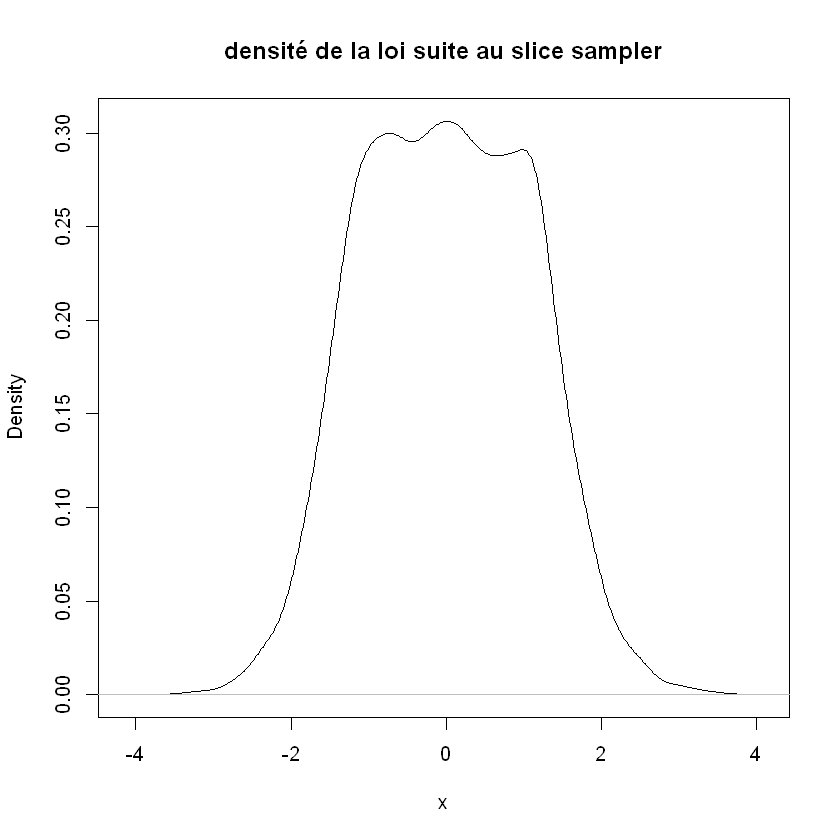

```r
x0=0.5

f<-function(x,d){
  return (1/2)*exp(-(x^2)/2)
}
x<-rep(x0,iterations)
u<-rep(runif(1,0,f(x[1],0.5)),iterations)


for (r in 2:iterations){
  u[r]=runif(1,0,f(x[r-1],0.5))
  x[r]=runif(1,-sqrt(-2*log(u[r],base=exp(1))),sqrt(-2*log(u[r],base=exp(1))))
}

plot(density(x),main="densité de la loi suite au slice sampler",xlab="x")

q11=quantile(x,0.5)
q12=quantile(x,0.75)
q13=quantile(x,0.8)
q14=quantile(x,0.9)
q15=quantile(x,0.95)
q16=quantile(x,0.99)
q17=quantile(x,0.995)
q18=quantile(x,0.999)
```

On voit que l'on a deux lois très proches après les itérations même en changeant le point d'initialisation.

```r
print(quantile(rnorm(iterations,0,1),0.5))
print(q1)
print(q11)
```

```
         50%
-0.002253346
        50%
0.008002908
        50%
-0.00975791
```

```r
print(quantile(rnorm(iterations,0,1),0.75))
print(q2)
print(q12)
```

```
      75%
0.6737529
      75%
0.8322628
      75%
0.8412391
```

```r
print(quantile(rnorm(iterations,0,1),0.8))
print(q3)
print(q13)
```

```
      80%
0.8496046
      80%
0.9955087
     80%
1.013254
```

```r
print(quantile(rnorm(iterations,0,1),0.9))
print(q4)
print(q14)
```

```
     90%
1.274729
     90%
1.372909
     90%
1.377998
```

```r
print(quantile(rnorm(iterations,0,1),0.95))
print(q5)
print(q15)
```

```
     95%
1.664164
     95%
1.695413
     95%
1.685887
```

```r
print(quantile(rnorm(iterations,0,1),0.99))
print(q6)
print(q16)
```

```
     99%
2.279377
     99%
2.337387
     99%
2.339445
```

```r
print(quantile(rnorm(iterations,0,1),0.995))
print(q7)
print(q17)
```

```
   99.5%
2.625849
   99.5%
2.601422
   99.5%
2.558304
```

```r
print(quantile(rnorm(iterations,0,1),0.999))
print(q8)
print(q18)
```

```
   99.9%
3.007492
   99.9%
3.000611
   99.9%
3.075659
```

On voit que pour des valeurs faibles de quantile (50% -> 80%) ou pour le quantile de 99.9%, on a un écart non négligeable entre la vraie valeur et la valeur obtenue grâce au slice sampler, ce qui peut s'expliquer par le fait que l'on n'a pas le pic de la loi normale. Mais les valeurs obtenues grâce au slice sampler sont quasiment les mêmes dans les deux cas à part pour le dernier quantile (99.9%).

#### Exercice 9.2

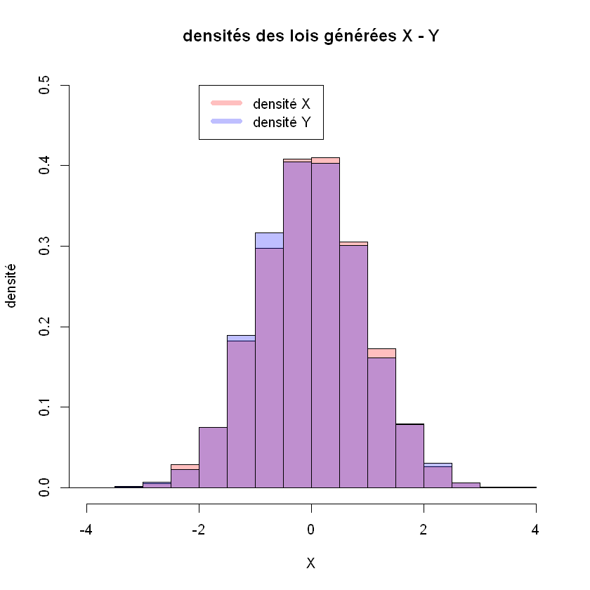

```r
iterations=10000
X=rep(0,iterations)
Y=rep(0,iterations)
p=0.3

for (t in 2:iterations){
  X[t]=rnorm(1,p*Y[t-1],1-(p*p))
  Y[t]=rnorm(1,p*X[t],1-(p*p))
}

hist(X,col=rgb(1,0,0,1/4),main="densités des lois générées X - Y",freq=FALSE, ylab="densité",ylim=c(0,0.5))
hist(Y,type="h",col=rgb(0,0,1,1/4),add=T,freq=FALSE)
legend(-2,0.5,legend=c("densité X","densité Y"),col=c(rgb(1,0,0,1/4),rgb(0,0,1,1/4)),lty=1,lwd=6)
```

On voit que l'on a la densité des deux chaines de Markov qui sont très semblables mais il faut suffisamment d'itérations (>1000 itérations) pour avoir ce cas. Lorsque l'on a énormément d'itérations, on finit par avoir la même densité pour ces deux chaines.

0.3165

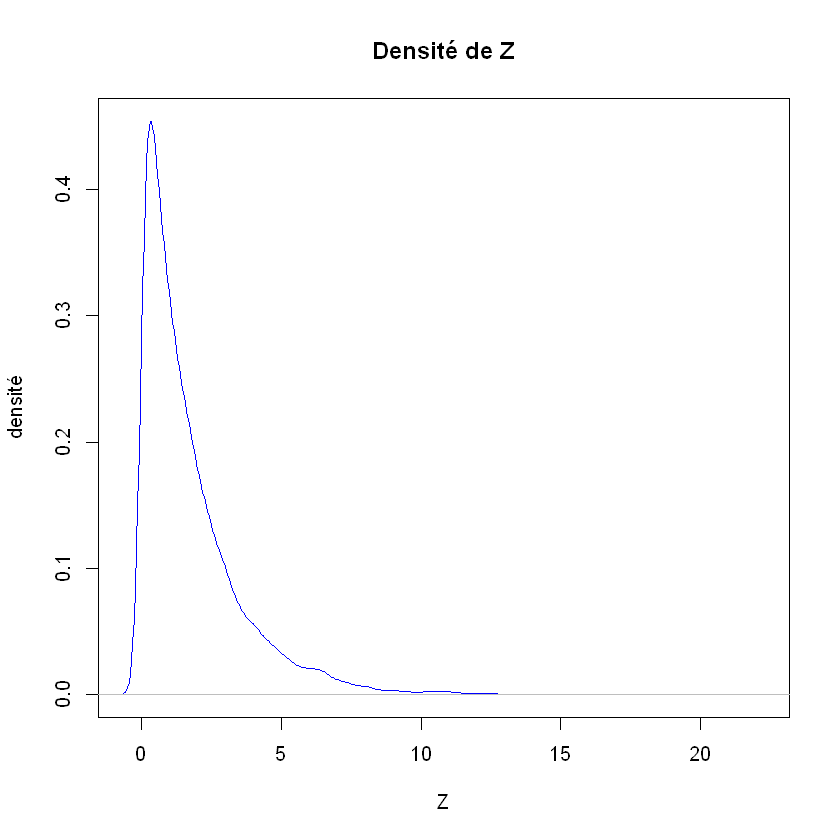

```r
Z=X^2+Y^2
plot(density(Z),type="l",xlab="Z",ylab="densité",lwd=1,col="blue",main="Densité de Z")

Zsup=Z[Z>2]
length(Zsup)/length(Z)
```

On a une probabilité d'environ 0.32 pour avoir Z>2 pour 10 000 itérations, cette valeur pourrait énormément varier surtout si l'on travaille sur peu d'itérations.